# Storm Data analysis: Tornados cause the most human damage, floods the most monetary damage

Rafael Monge

December 22, 2015

# Synopsis

This project involves explores the U.S. National Oceanic and Atmospheric Administration’s (NOAA) storm database. This database tracks characteristics of major storms and weather events in the United States, including when and where they occur, as well as estimates of any fatalities, injuries, and property damage.

The data is used to discover which types of events are the most harmful, both from an economic and a human perspective. Our analysis shows that the most harmful in human terms (injuries and fatalities) are tornadoes. Meanwhile, the ones with the highest monetary cost are Floods.

# Data Processing

The preprocessing done to the data is:

```r
library(dplyr)
```

```r
library(stringdist)
library(ggplot2)
```

```r
file <- "repdata_data_StormData.csv.bz2"
url <- "https://d396qusza40orc.cloudfront.net/repdata%2Fdata%2FStormData.csv.bz2"
if(!file.exists(file)){
  download.file(url, file)
}
stormData <- read.csv(file, stringsAsFactors = FALSE)
stormData <-tbl_df(stormData)

vectorMultiplier <- list(K = 1000, M= 1000000,B=1000000000, H=100,"+" = 100, "-" = 1, "?" = 1, "0" = 1)
ValidEventTypes <- toupper(c('Astronomical Low Tide ','Avalanche ','Blizzard ','Coastal Flood','Cold/Wind Chill ','Debris Flow','Dense Fog','Dense Smoke ','Drought ','Dust Devil ','Dust Storm ','cessive Heat ','Extreme Cold/Wind Chill','Flash Flood','Flood ','Freezing Fog','Frost/Freeze','Funnel Cloud','Hail ','Heat ','Heavy Rain','Heavy Snow','High Surf','High Wind','Hurricane/Typhoon','Ice Storm ','Lakeshore Flood','Lake-Effect Snow','Lightning ','Marine Hail ','Marine High Wind ','Marine Strong Wind','Marine Thunderstorm Wind','Rip Current ','Seiche ','Sleet ','Storm Surge/Tide','Strong Wind','Thunderstorm Wind','Tornado ','Tropical Depression ','Tropical Storm','Tsunami ','Volcanic Ash','Waterspout ','Wildfire ','Winter Storm ','Winter Weather'))


ExpTransform <- function(value, exp){
  if(exp == ""){
    1000*value
  }
  else if(exists(exp,where=vectorMultiplier))
    value *vectorMultiplier[[exp]]

  else
    value *as.numeric(exp)
}

ExpTransformVectorized <-  Vectorize(ExpTransform, vectorize.args = c("value", "exp"))
TransformedEventType<- function(x){

  index<- which.min(stringdist(x, ValidEventTypes, method ="lcs"))
  ValidEventTypes[index]
}
VectorizedTransformedEventType <- Vectorize(TransformedEventType, vectorize.args = c("x"))


#VectorizedPopulationDamage <- Vectorize(PopulationDamage, vectorize.args = c("injuries", "fatalities"))


stormDataTrim <- stormData %>%
  select (BGN_DATE, EVTYPE, FATALITIES, INJURIES, PROPDMG, PROPDMGEXP, CROPDMG, CROPDMGEXP) %>%
  arrange(EVTYPE) %>%
  mutate (PROPDMGEXP = toupper(PROPDMGEXP)
          ,CROPDMGEXP= toupper(CROPDMGEXP)
          ,EVTYPE= toupper(EVTYPE)
          ,PropertyDamage = ExpTransformVectorized(PROPDMG, PROPDMGEXP)
          ,CropDamage = ExpTransformVectorized(CROPDMG, CROPDMGEXP)
          ,EventType = VectorizedTransformedEventType(EVTYPE)
  ) %>%
  group_by(EventType) %>%
  summarize(INJURIES = sum(INJURIES)
            , FATALITIES=sum(FATALITIES)
            , CropDamage=sum(CropDamage)
            , PropertyDamage=sum(PropertyDamage)) %>%
  mutate(PopulationCost = INJURIES + FATALITIES *5
         , MonetaryCost = CropDamage  + PropertyDamage
         , PopulationFactor = reorder(EventType,PopulationCost )
         , MonetaryFactor = reorder(EventType,MonetaryCost )) %>%
  select (EventType,PopulationCost, MonetaryCost,PopulationFactor,MonetaryFactor )
```

# Results

## Population cost.

The following are the the top 5 event types which cause the highest population damage. Tornadoes are the ones with the highest cost.

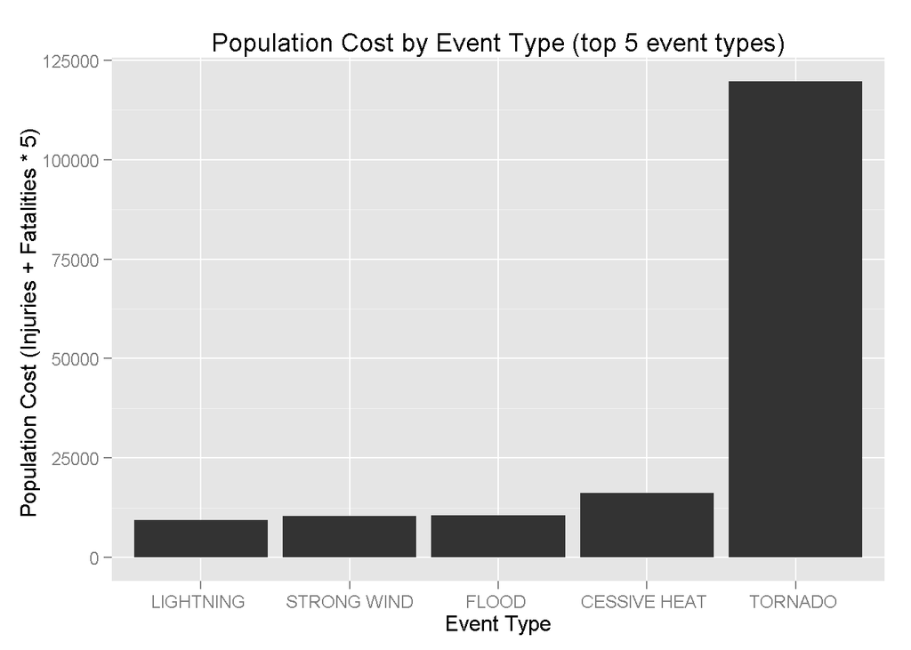

```r
stormDataTrim %>% top_n(5,PopulationCost) %>%
ggplot(aes(PopulationFactor, PopulationCost))+
  geom_bar(stat = "identity") +
  xlab("Event Type") +
  ylab("Population Cost (Injuries + Fatalities * 5) ") +
  ggtitle("Population Cost by Event Type (top 5 event types)")
```

## Monetary cost.

The following are the the top 5 event types which cause the highest monetary damage. Floods are the ones with the highest cost.

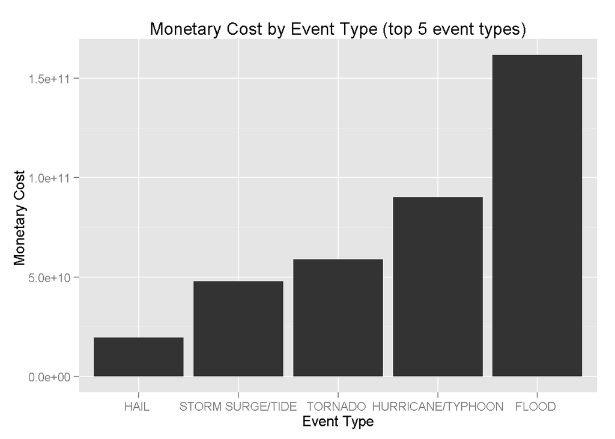

```r
stormDataTrim %>% top_n(5,MonetaryCost) %>%
  ggplot(aes(MonetaryFactor, MonetaryCost))+
  geom_bar(stat = "identity") +
  xlab("Event Type") +
  ylab("Monetary Cost ") +
  ggtitle("Monetary Cost by Event Type (top 5 event types)")
```